# MNS_Practical 5

## MNS_Practical 5: Leonard Hollander

## Part 1: Synaptic current

```python
import numpy as np
import matplotlib.pyplot as plt
import math
```

```python
#Part (a) – Single pre-synaptic spikes:

tau_syn, tau_m = 10, 10
R_m = 1e7
E_m = -80

#Spike in nS:

g_ast = 30
V_0 = E_m
R_mI_m = 0

#Inhibitory and Excitatory synapses in mV:

E_inh = -100
E_exc = 0

#Post-synaptic current:

E_inh = -100
E_exc = 0
```

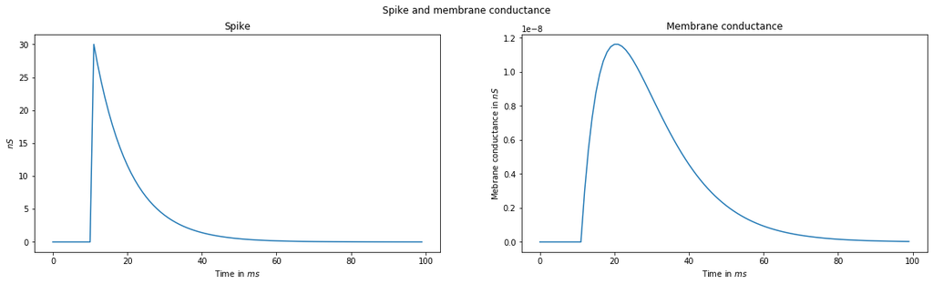

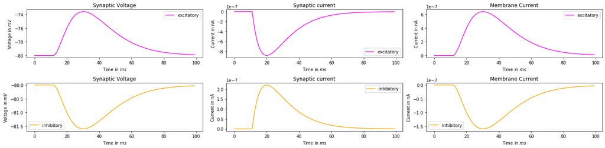

```python
#Importing the Euler-function from the last exercise sheet:

def euler(f_func, x_0, t_max, dt):

    x = x_0
    nsteps = int(t_max / dt)
    xs = np.zeros(nsteps)
    xs[0] = x_0
    i = 1
    t = 0

    while i < nsteps:

        x = x + f_func(x,t)*dt
        xs[i] = x
        t += dt
        i += 1

    return xs

#Euler-specific parameters:

t_max = 100
dt = 1

#Setting the Spike Time:

t_spike = 10

#Simulating the membrane conductance:

spike = euler(lambda x, t: (-x  + tau_syn * g_ast * 1/dt * (t == t_spike)) / tau_syn ,0, t_max, dt)
g_syn = euler(lambda g_syn, t: (spike[t] - g_syn) / tau_syn, 0, t_max, dt)


g_syn = g_syn * 1e-9 #Converting to Siemens

#Synaptic voltage:

V_inh = euler(lambda V, t: (-V + E_m - g_syn[t] * R_m * (V - E_inh))/ tau_m, 0 + E_m, t_max, dt)
V_exc = euler(lambda V, t: (-V + E_m - g_syn[t] * R_m * (V - E_exc))/ tau_m, 0 + E_m, t_max, dt)

#Synaptic current:

I_syn_inh = g_syn*(V_inh - E_inh)
I_syn_exc = g_syn*(V_exc - E_exc)

#Membrane current:

I_m_inh = (V_inh - E_m) / R_m
I_m_exc = (V_exc - E_m) / R_m

#Plotting things:

fig, axs = plt.subplots(1,2, figsize = (20,5))

plt.suptitle('Spike and membrane conductance')

axs[0].plot(spike)
axs[0].set_xlabel('Time in $ms$')
axs[0].set_ylabel('$nS$')
axs[0].set_title('Spike')
axs[1].plot(g_syn)
axs[1].set_xlabel('Time in $ms$')
axs[1].set_ylabel('Mebrane conductance in $nS$')
axs[1].set_title('Membrane conductance')

plt.figure()

fig, axs = plt.subplots(2,3, figsize = (20,5))

axs[0,0].plot(V_exc, c = 'magenta', label = 'excitatory')
axs[0,0].set_xlabel('Time in $ms$')
axs[0,0].set_ylabel('Voltage in $mV$')
axs[0,0].set_title('Synaptic Voltage')
axs[0,0].legend()
axs[0,1].plot(I_syn_exc, c = 'magenta', label = 'excitatory')
axs[0,1].set_xlabel('Time in $ms$')
axs[0,1].set_ylabel('Current in nA')
axs[0,1].set_title('Synaptic current')
axs[0,1].legend()
axs[0,2].plot(I_m_exc, c = 'magenta', label = 'excitatory')
axs[0,2].set_xlabel('Time in $ms$')
axs[0,2].set_ylabel('Current in nA')
axs[0,2].set_title('Membrane Current')
axs[0,2].legend()

axs[1,0].plot(V_inh, c = 'orange', label = 'inhibitory')
axs[1,0].set_xlabel('Time in $ms$')
axs[1,0].set_ylabel('Voltage in $mV$')
axs[1,0].set_title('Synaptic Voltage')
axs[1,0].legend()
axs[1,1].plot(I_syn_inh, c = 'orange', label = 'inhibitory')
axs[1,1].set_xlabel('Time in $ms$')
axs[1,1].set_ylabel('Current in nA')
axs[1,1].set_title('Synaptic current')
axs[1,1].legend()
axs[1,2].plot(I_m_inh, c = 'orange', label = 'inhibitory')
axs[1,2].set_xlabel('Time in $ms$')
axs[1,2].set_ylabel('Current in nA')
axs[1,2].set_title('Membrane Current')
axs[1,2].legend()

plt.tight_layout()
```

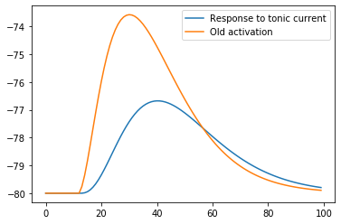

```python
#Part (b) – Shunting inhibition:

# Isyn(t) = gsyn(t)(V (t) − Esyn) + gexc(V (t) − Eexc) + ginh(V (t) − Einh)

g_exc = 5e-1
g_inh = 2e0

I_syn_new = lambda t: g_syn[t] * (V_inh[t] - E_exc) + g_exc *(V_inh[t] - E_exc) + g_inh * (V_inh[t] - E_inh)

V_new = euler(lambda V, t: (-V + E_m - I_syn_new(t)) / tau_m, 0 + E_m, t_max, dt)

plt.plot(V_new, label = 'Response to tonic current')
plt.plot(V_exc, label = 'Old activation')
plt.legend()
```

## Part 2: Integrate and fire neuron:

```
-80
<function <lambda> at 0x11c30c950>
```

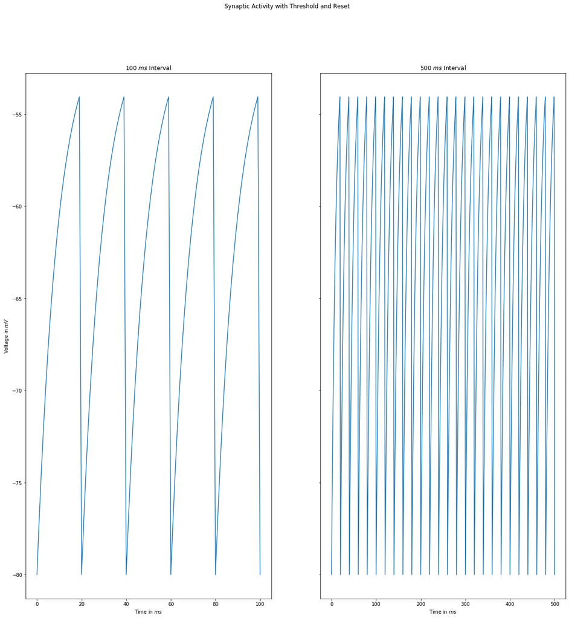

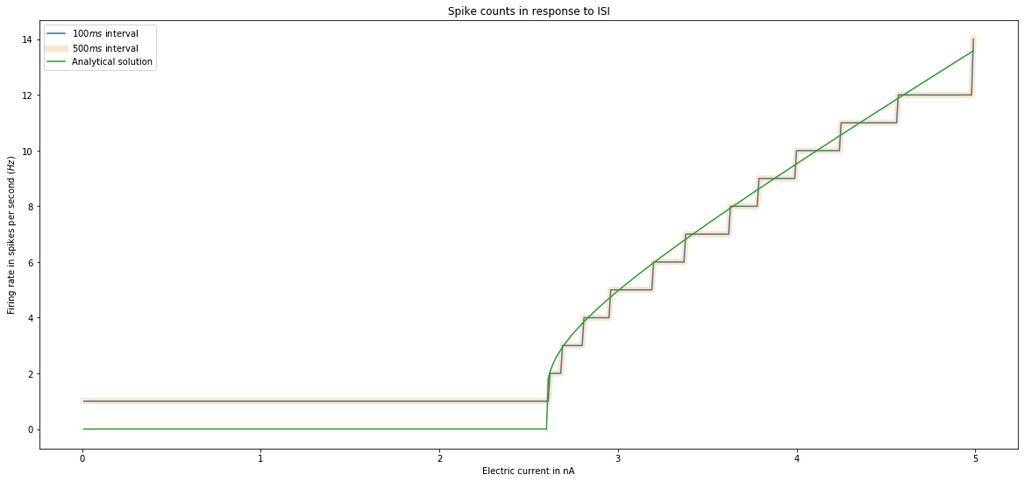

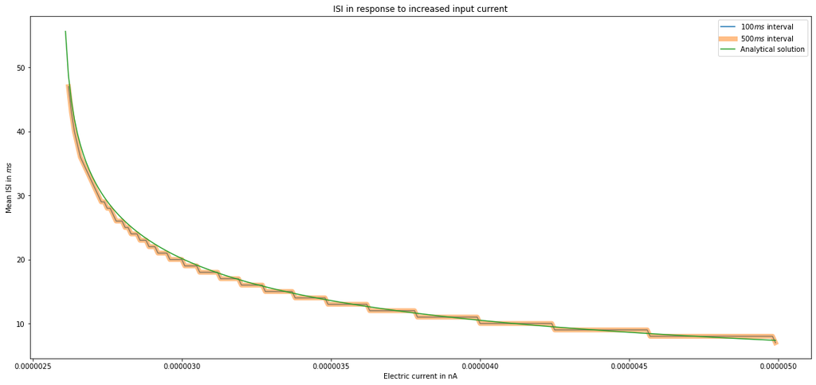

```python
#Part (a): Resetting upon hitting the threshold

I_e = 3e-6

V_thresh = -54

V_reset = -80

def euler_mod(f_func, x_0, t_max, dt):

    x = x_0
    nsteps = int(t_max / dt)
    xs = np.zeros(nsteps)
    xs[0] = x_0
    i = 1
    t = 0

    while i < nsteps:

        x = x + f_func(x,t)*dt

        if x > V_thresh:
            xs[i] = V_reset

        else:
            xs[i] = x

        x = xs[i]
        t += dt
        i += 1

    return xs

print(E_m)

V = euler_mod(lambda V, t: (-V + E_m + R_m * 3e-6) / tau_m, 0 +  E_m , 101, dt)
V_500 = euler_mod(lambda V, t: (-V + E_m + R_m * 3e-6) / tau_m, 0 + E_m, 501, dt)

fig, axs = plt.subplots(1,2, sharey = True, sharex = False, figsize = (20,20))

plt.suptitle('Synaptic Activity with Threshold and Reset')

axs[0].plot(V)
axs[0].set_title('100 $ms$ Interval')
axs[0].set_xlabel('Time in $ms$')
axs[0].set_title('100 $ms$ Interval')
axs[1].plot(V_500)
axs[1].set_title('500 $ms$ Interval')
axs[1].set_xlabel('Time in $ms$')
axs[0].set_ylabel('Voltage in $mV$')

#Get the number of spikes

num_spikes = lambda V: list(V).count(np.max(V))
firing_rate = lambda V: num_spikes(V) / len(V)

print(firing_rate)

#Calculate the firing_rate:

I_es = np.arange(.01,5, .01) * 1e-6

fr = lambda x: num_spikes(euler_mod(lambda V, t: (-V + E_m + R_m * x) / tau_m, 0 +  E_m , 101 , dt))
fr_500 = lambda x: num_spikes(euler_mod(lambda V, t: (-V + E_m + R_m * x) / tau_m, 0 +  E_m , 101 , dt))

frs = np.array(list(map(fr, I_es)))
frs_500 = np.array(list(map(fr_500, I_es)))

#Analytical solution:

fr_analytical = lambda I_e: 1 / (tau_m * np.log((R_m * I_e + E_m - V_reset) / (R_m * I_e + E_m - V_thresh)))

fr_analytical = list(map(fr_analytical, I_es))

#Multyplying with 100 to get the spike count over the full interval

fr_analytical = [0 if np.isnan(k) else k*100 for k in fr_analytical]

#Get the ISIs: We calculate the first two maxima and and use their distance:

def peaks(V):

    temp = [i for i, j in np.ndenumerate(V) if j == np.max(V)]

    return [x for tup in temp for x in tup]

dist = lambda V: [V[i+1] - V[i] for i in range(len(V) - 1)]

isi = lambda V: np.mean(dist(peaks(V)))

#Same as before, we want to apply these functions to our I_e values:

get_isi = lambda x: isi(euler_mod(lambda V, t: (-V + E_m + R_m * x) / tau_m, 0 +  E_m , 101 , dt))
get_isi_500 = lambda x: isi(euler_mod(lambda V, t: (-V + E_m + R_m * x) / tau_m, 0 +  E_m , 101 , dt))

isis = np.array(list(map(get_isi, I_es)))
isis_500 = np.array(list(map(get_isi_500, I_es)))

#ISI analytical:

isi_analytical = 1 / np.array(fr_analytical)

plt.figure(figsize = (20,9))
plt.title('Spike counts in response to ISI')
plt.plot(I_es * 1e6, frs, label = '100$ms$ interval ')
plt.plot(I_es * 1e6, frs_500, label = '500$ms$ interval', alpha = .2, linewidth = 7)
plt.ylabel('Firing rate in spikes per second ($Hz$)')
plt.xlabel('Electric current in nA')
plt.plot(I_es *1e6, fr_analytical, label = 'Analytical solution')
plt.legend()

plt.figure(figsize = (20,9))
plt.title('ISI in response to increased input current')
plt.xlabel('Electric current in nA')
plt.plot(I_es, isis, label = '100$ms$ interval ')
plt.ylabel('Mean ISI in $ms$')
plt.plot(I_es, isis_500, linewidth = 7, alpha = .5, label = '500$ms$ interval' )
plt.plot(I_es, isi_analytical*100, label ='Analytical solution')
plt.legend()
```

$\textit{Top-figure}$: The $ISI$ in this case is 20 $ms$ and hence the firing rate is $\frac{1}{20}$ $\frac{spikes}{ms}$. The number of spikes is 5. We can estimate the firing rate by divinding the total time interva by the number of spikes, which would give us the same result. In this case, therefore, the inverse $ISI$ and firing rate correspond (this is as expected). Moreover, nothing changes between the two different time intervals. Using some quick estimations, we can verify that the firing rate is indeed the inverse of the $ISI$. $\textit{Middle-figure}$: As we should expect, the firing rate increases as a function of the applied current. The empirical results from this model decently approximate the analytical solution. $\textit{Bottom-figure:}$ The Mean $ISI$ – again, as expected – decreases as a function of applied current. And again, the empirical results approximate the analytical predictions.

## Synaptically coupled IF neurons

Didn't finish 3.

```python
#Updating conductance, voltage and spike all at the same time:

#This should have been the logic from the very beginning:

def euler_mod2(v_0, c_0, spike_t, t_max, dt):

    nsteps = int(t_max / dt)
    spike_arr = np.zeros(nsteps)
    spike = 0
    spike_arr[0] = spike
    i = 1
    t = 0

    #Conductances:

    cond = c_0
    cond_arr = np.zeros(nsteps)
    cond_arr[0] = cond

    #Voltages

    v_inh = v_0
    v_exc = v_0
    voltinh_arr = np.zeros(nsteps)
    voltexc_arr = np.zeros(nsteps)
    voltinh_arr[0] = v_inh
    voltexc_arr[0] = v_exc


    #Implementing the logic of the

    while i < nsteps:

        spike += (-spike + tau_syn * g_ast * 1/dt * (t == spike_t)) * dt / tau_syn
        spike_arr[i] = spike

        cond += (spike - cond) * dt / tau_syn
        cond_arr[i] = cond

        v_inh += ((-v_inh + E_m - cond * 1e-9 * R_m * (v_inh - E_inh)) / tau_m) * dt
        voltinh_arr[i] = v_inh
        v_exc += ((-v_exc + E_m - cond  * 1e-9 * R_m * (v_exc - E_exc)) / tau_m) * dt
        voltexc_arr[i] = v_inh

        i += 1
        t += dt

    return spike_arr, cond_arr, voltinh_arr, voltexc_arr

#Now, do this with thresholds and spikes for only one neuron:


def euler_mod3(v1_0, v2_0, c1_0, c2_0, t_max, dt, V_thresh, V_reset):

    nsteps = int(2 * t_max / dt)
    i = 1
    t = 0

    #Spikes:

    spike1 = 0
    spike2 = 0
    spike1_t = 0
    spike2_t = np.inf

    #Conductances:

    cond1 = c1_0
    cond1_arr = np.zeros(nsteps)
    cond1_arr[0] = cond1

    cond2 = c2_0
    cond2_arr = np.zeros(nsteps)
    cond2_arr[0] = cond2


    #Voltages (inhibitory):

    volt1 = v1_0
    volt1_arr = np.zeros(nsteps)
    volt1_arr[0] = volt1

    volt2 = v2_0
    volt2_arr = np.zeros(nsteps)
    volt2_arr[0] = volt2


    #Implementing the logic of the euler function: I should have done this much earlier.
    #Would have saved myself a lot of trouble

    #Let's say the folllwing thing: whenever one of them is reset we count that as a spike
    #Update each neuron on the basis of what the spikes in the other one are doing

    #And the code works by updating the spike_times:

    while i < nsteps:

        ind = int(i)

        if (i % 2 == 0): #update first neuron


            spike1 += (-spike1 + tau_syn * g_ast * 1/dt * (t == spike2_t)) *dt / tau_syn
            #spike1_arr[i/2] = spike1

            cond1 += (spike2 - cond1) * dt / tau_syn
            cond1_arr[ind] = cond1

            volt1 += ((-volt1 + E_m - cond1 * 1e-9 * R_m * (volt1 - E_m)) / tau_m) * dt

            if volt1 > V_reset:

                volt1_arr[ind] = V_reset
                spike1_t = t

            else:

                volt1_arr[ind] = volt1

            volt1 = volt1_arr[ind]

        else:

            spike2 += (-spike2 + tau_syn * g_ast * 1/dt * (t == spike1_t)) *dt / tau_syn
            #spike2_arr[int(i/2)] = spike2

            cond2 += (spike1 - cond2) * dt / tau_syn
            cond2_arr[ind] = cond2

            volt2 += ((-volt2 + E_m - cond2 * 1e-9 * R_m * (volt2 - E_m)) / tau_m) * dt

            if volt1 > V_reset:

                ind = i / 2
                volt2_arr[ind] = V_reset
                spike2_t = t

            else:

                volt2_arr[ind] = volt2

            volt2 = volt2_arr[ind]


        i += 1
        t += dt

    return cond1_arr, cond2_arr, volt1_arr, volt2_arr
```